# Custom ODE solvers in Stan - Part 1

Juho Timonen

3/13/2020

The R functions and `.stan` files used in this vignette can be found [here](https://github.com/jtimonen/odeint-stan).

```r
require(rstan)
source('functions.R')
rstan_options(auto_write = TRUE)
color_scheme_set("red")
```

## 1. Defining a toy system

Here we study a Lotka-Volterra system

$$\frac{d\boldsymbol{x}(t)}{dt} = f \left( \boldsymbol{x}(t), \boldsymbol{\theta}\right)$$
where
$$f \left( \boldsymbol{x}, \boldsymbol{\theta} \right) =
\begin{bmatrix}
x_1 - \theta_1 x_1 x_2 \\
\theta_1 x_1 x_2- \theta_2 x_2
\end{bmatrix}$$
with $x_1(0) = 1$ and $x_2(0) = 2$. We create a Stan model and expose its functions to R.

```r
t0    <- 0
y0    <- c(1,2)
model <- stan_model('stan/main.stan')
```

```r
funs <- expose_stan_functions(model)
print(funs)
```

```
## [1] "odefun"      "odefun_vec"  "interpolate" "rk45_boost"  "euler_fixed"
## [6] "euler"       "rk4_fixed"   "rk4"
```

The `odefun` function implements $f$. Functions `rk45_boost`, `euler`, `rk4`, `euler_fixed` and `rk4_fixed` are ODE integration methods that call `odefun` several times.

## 2. Using the exposed ODE solvers

We first demonstrate how to use the RK45 method exposed to R:

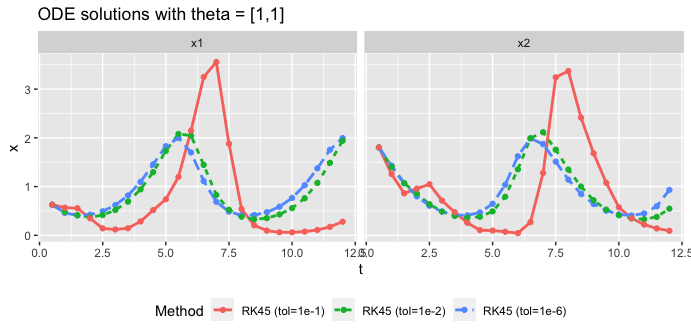

```r
t_out  <- seq(0.5,12,by=0.5)
theta  <- c(1,1)     # parameter values
y_out1 <- odeint(rk45_boost, y0, t0, t_out, theta)
y_out1b <- odeint(rk45_boost, y0, t0, t_out, theta, abs_tol = 0.01, rel_tol = 0.01)
y_out1c <- odeint(rk45_boost, y0, t0, t_out, theta, abs_tol = 0.1, rel_tol = 0.1)
Y_out  <- list(y_out1, y_out1b, y_out1c)
names <- c("RK45 (tol=1e-6)", "RK45 (tol=1e-2)", "RK45 (tol=1e-1)")
plot_traj(t_out, Y_out, names) + geom_point()
```

These are the solutions with different absolute and relative tolerances for the RK45 method.

## 3. ODE solvers with fixed time step

The `_fixed` versions use a fixed time step and then linear interpolation to get the output at desired, possibly unequally spaced, time points.

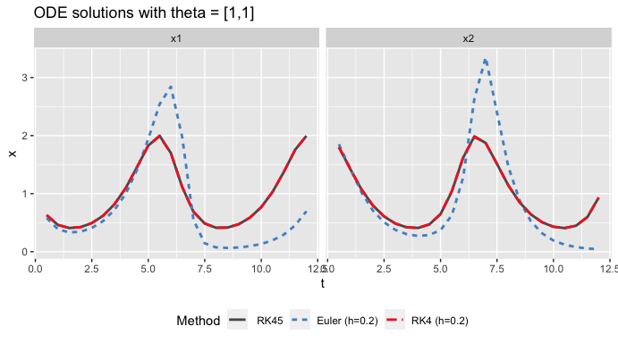

```r
names <- c(" RK45", "Euler (h=0.2)", "RK4 (h=0.2)")
colors <- c('gray35', 'steelblue3', 'firebrick2')
y_out2 <- odeint(euler_fixed, y0, t0, t_out, theta, step_size = 0.2)
y_out3 <- odeint(rk4_fixed, y0, t0, t_out, theta, step_size = 0.2)
Y_out  <- list(y_out1, y_out2, y_out3)
plot_traj(t_out, Y_out, names) + scale_color_manual(values=colors)
```

The output of RK45 and RK4 are indistinguishable in this case. Euler’s method would need a much smaller step size (`h`) to get even close in terms of global error.

## 4. ODE solvers with time step defined by output time points

These solvers on the other hand determine the step size based on the desired output time points. Because our output time grid is equispaced with intervals $\Delta t = 0.5$, and we specify `n_steps_per_timepoint=2`, our step size will actually be fixed also here ($0.25$).

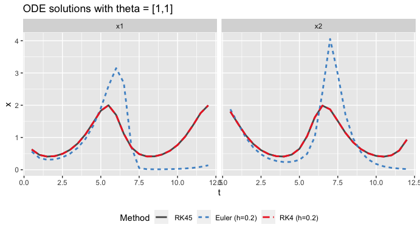

```r
y_out4 <- odeint(euler, y0, t0, t_out, theta, n_steps_per_timepoint=2)
y_out5 <- odeint(rk4, y0, t0, t_out, theta, n_steps_per_timepoint=2)
Y_out  <- list(y_out1, y_out4, y_out5)
plot_traj(t_out, Y_out, names) + scale_color_manual(values=colors)
```